```r
library(Seurat)
library(cowplot)
library(harmony)
```

# Seurat V3 Interface

This brief vignette demonstrates how to use Harmony with Seurat V3. This example closely follows the Seurat vignette: https://satijalab.org/seurat/v3.0/immune_alignment.html

To begin, download the sparse gene count [matrices](https://www.dropbox.com/s/t06tptwbyn7arb6/pbmc_stim.RData?dl=1) and move them somewhere convenient (e.g. data/).

```r
load('data/pbmc_stim.RData')
```

## Initialize Seurat Object

Before running Harmony, make a Seurat object and following the standard pipeline through PCA.

*IMPORTANT DIFFERENCE:* In the Seurat integration tutorial, you need to define a Seurat object for each dataset. With Harmony integration, create only one Seurat object with all cells.

```r
pbmc <- CreateSeuratObject(counts = cbind(stim.sparse, ctrl.sparse), project = "PBMC", min.cells = 5) %>%
    Seurat::NormalizeData(verbose = FALSE) %>%
    FindVariableFeatures(selection.method = "vst", nfeatures = 2000) %>%
    ScaleData(verbose = FALSE) %>%
    RunPCA(pc.genes = pbmc@var.genes, npcs = 20, verbose = FALSE)
```

Make sure that the dataset ID is in the object's metadata. Here, we define datasets with the variable *stim*.

```r
pbmc@meta.data$stim <- c(rep("STIM", ncol(stim.sparse)), rep("CTRL", ncol(ctrl.sparse)))
```

There is a clear difference between the datasets in the uncorrected PCs

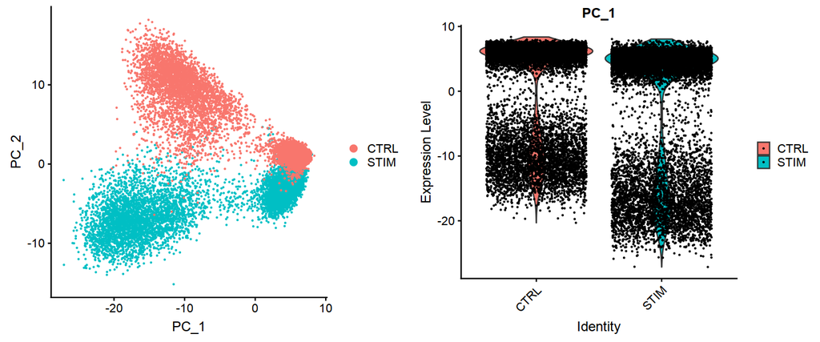

```r
options(repr.plot.height = 5, repr.plot.width = 12)
p1 <- DimPlot(object = pbmc, reduction = "pca", pt.size = .1, group.by = "stim", do.return = TRUE)
p2 <- VlnPlot(object = pbmc, features = "PC_1", group.by = "stim", do.return = TRUE, pt.size = .1)
plot_grid(p1,p2)
```

## Run Harmony

The simplest way to run Harmony is to pass the Seurat object and specify which variable(s) to integrate out. RunHarmony returns a Seurat object, updated with the corrected Harmony coordinates. Let's set plot_convergence to TRUE, so we can make sure that the Harmony objective function gets better with each round.

```
Harmony 1/10
Harmony 2/10
Harmony 3/10
Harmony 4/10
Harmony 5/10
Harmony 6/10
Harmony 7/10
Harmony 8/10
Harmony converged after 8 iterations
```

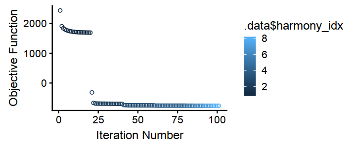

```r
options(repr.plot.height = 2.5, repr.plot.width = 6)
pbmc <- pbmc %>%
    RunHarmony("stim", plot_convergence = TRUE)
```

To directly access the new Harmony embeddings, use the *Embeddings* command.

```r
harmony_embeddings <- Embeddings(pbmc, 'harmony')
harmony_embeddings[1:5, 1:5]
```

1. 25894

2. 20

A matrix: 5 × 5 of type dbl

|  | harmony_1 | harmony_2 | harmony_3 | harmony_4 | harmony_5 |
| --- | --- | --- | --- | --- | --- |
| AAACATACCAAGCT-1 | 3.959337 | -0.9887445 | -4.9379311 | -6.118842 | -1.8354619 |
| AAACATACCCCTAC-1 | -1.631977 | -0.9337078 | 7.7300758 | -8.842865 | -2.9982345 |
| AAACATACCCGTAA-1 | 5.798815 | 1.6570520 | 0.6685604 | 1.148935 | -0.2856785 |
| AAACATACCCTCGT-1 | 2.838795 | -1.2805793 | 7.2660363 | -1.711304 | 1.0466651 |
| AAACATACGAGGTG-1 | 6.783708 | -0.2450474 | 0.4836541 | 2.962785 | -0.5428238 |

Let's make sure that the datasets are well integrated in the first 2 dimensions after Harmony.

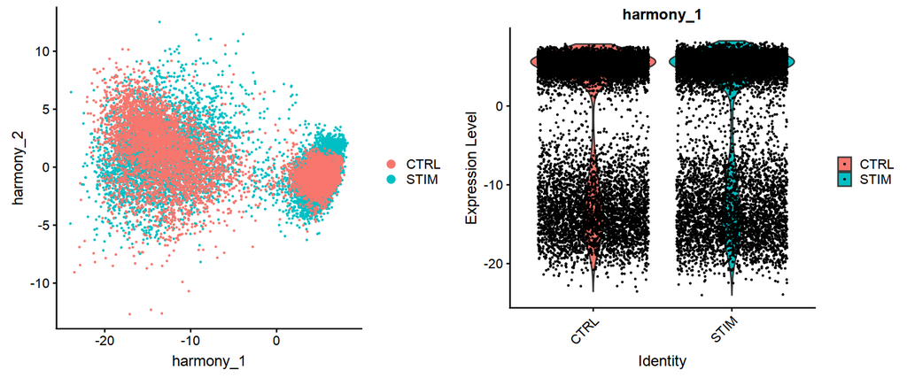

```r
options(repr.plot.height = 5, repr.plot.width = 12)
p1 <- DimPlot(object = pbmc, reduction = "harmony", pt.size = .1, group.by = "stim", do.return = TRUE)
p2 <- VlnPlot(object = pbmc, features = "harmony_1", group.by = "stim", do.return = TRUE, pt.size = .1)
plot_grid(p1,p2)
```

## Downstream analysis

Many downstream analyses are performed on low dimensional embeddings, not gene expression. To use the corrected Harmony embeddings rather than PCs, set *reduction = 'harmony'*. For example, let's perform the UMAP and Nearest Neighbor analyses using the Harmony embeddings.

```r
pbmc <- pbmc %>%
    RunUMAP(reduction = "harmony", dims = 1:20) %>%
    FindNeighbors(reduction = "harmony", dims = 1:20) %>%
    FindClusters(resolution = 0.5) %>%
    identity()
```

```
Modularity Optimizer version 1.3.0 by Ludo Waltman and Nees Jan van Eck

Number of nodes: 25894
Number of edges: 854286

Running Louvain algorithm...
Maximum modularity in 10 random starts: 0.9057
Number of communities: 14
Elapsed time: 5 seconds
```

In the UMAP embedding, we can see more intricate structure. Since we used harmony embeddings, the UMAP embeddings are well mixed.

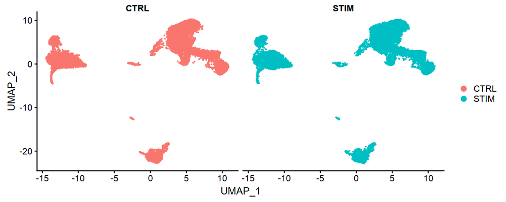

```r
options(repr.plot.height = 4, repr.plot.width = 10)
DimPlot(pbmc, reduction = "umap", group.by = "stim", pt.size = .1, split.by = 'stim')
```

In this well mixed embedding, we can start identifying shared cell types with clustering analysis.

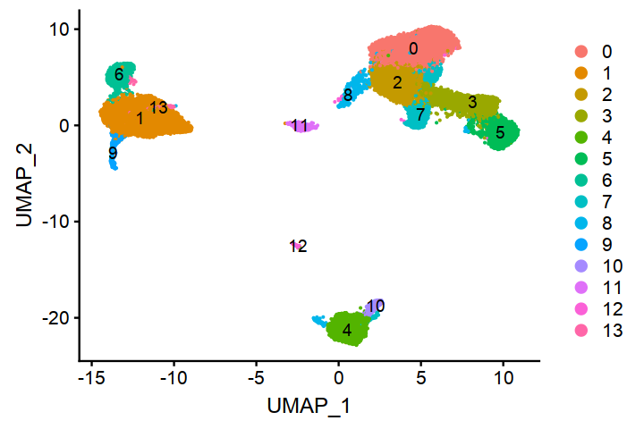

```r
options(repr.plot.height = 4, repr.plot.width = 6)
DimPlot(pbmc, reduction = "umap", label = TRUE, pt.size = .1)
```